# hw2a

```r
# Question 1
data <- read.csv("NBA.csv")
```

Question 1: Load the dataset into a dataframe, and convert all categorical data into factors

```r
# Question 2
is.na(data)
```

[output not shown]

[output cut: 1443 more lines]

```r
data_omit <- na.omit(data)
```

Question 2: Checked for N/A form out data set and dropped into a new data set called data_omit

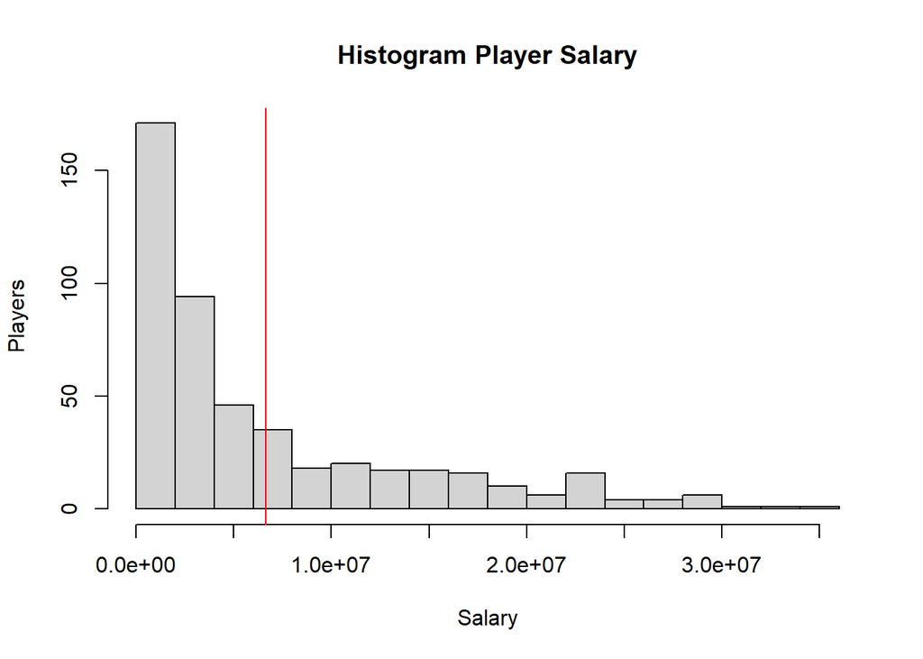

```r
# Question 3
hist(data_omit$Salary,  breaks = 15, main = "Histogram Player Salary", xlab = "Salary", ylab = "Players")
abline(v = mean(data_omit$Salary), col = "red")
```

```r
mean(data_omit$Salary)
```

```
## [1] 6660622
```

Question 3: What do you learn from the plot? Well first of all the histogram is in ordered salary and not player frequency so when we plot abline mean of the salary it is not centered. We can see that the mean of the salary is 6,660,622 and that at the 15 bin size the lowest bin salary has the most amount of players and the height of the histogram shrinks as the salary increase.

```r
# Question 4
games_played50 <- data_omit[which(data_omit$G >= 50),]
games_played50[which.max(games_played50$PER),]
```

```
##           Player   Salary NBA_Country NBA_DraftNumber Age  Tm  G   MP  PER
## 296 James Harden 28299399         USA               3  28 HOU 69 2449 30.2
##       TS. X3PAr   FTr ORB. DRB. TRB. AST. STL. BLK. TOV. USG.  OWS DWS WS WS.48
## 296 0.619 0.499 0.498  1.8 15.4  8.6 44.8  2.5  1.7 14.7 36.2 11.4 3.6 15 0.294
##     OBPM DBPM  BPM VORP
## 296  9.8  1.3 11.1  8.1
```

```r
games_played50[which.max(games_played50$TS),]
```

```
##           Player   Salary NBA_Country NBA_DraftNumber Age  Tm  G   MP  PER
## 70 Stephen Curry 34682550         USA               7  29 GSW 51 1631 28.2
##      TS. X3PAr  FTr ORB. DRB. TRB. AST. STL. BLK. TOV. USG. OWS DWS  WS WS.48
## 70 0.675  0.58 0.35  2.7 14.4  8.9 30.2  2.4  0.4 13.3   31 7.2 1.9 9.2  0.27
##    OBPM DBPM BPM VORP
## 70  9.8 -1.2 8.6  4.4
```

```r
games_played50[which.max(games_played50$VORP),]
```

```
##           Player   Salary NBA_Country NBA_DraftNumber Age  Tm  G   MP  PER  TS.
## 194 LeBron James 33285709         USA               1  33 CLE 78 2898 28.5 0.62
##     X3PAr  FTr ORB. DRB. TRB. AST. STL. BLK. TOV. USG.  OWS DWS   WS WS.48 OBPM
## 194 0.254 0.33  3.6 22.3 13.1   44  1.9  2.1 15.9 31.4 10.4   3 13.4 0.222  7.5
##     DBPM BPM VORP
## 194  2.2 9.7  8.6
```

Question 4: Which player with at least 50 games played led the league in PER? James Harden at 69 games played and 30.2 PER  
TS? Stephen Curry at 51 games played and 0.675 TS. VORP? LeBron James at 78 games played and 8.6 VORP

```r
# Question 5
SC <- data_omit[data_omit$Player == "Stephen Curry",]
length(which(data_omit$PER > SC$PER))/nrow(data_omit)
```

```
## [1] 0.01449275
```

```r
length(which(data_omit$TS > SC$TS))/nrow(data_omit)
```

```
## [1] 0.02070393
```

```r
length(which(data_omit$VORP > SC$VORP))/nrow(data_omit)
```

```
## [1] 0.02070393
```

Question 5: What percent of players had a higher PER than Stephen Curry? 1.449275% had higher PER but may had less then 50 games played Higher TS? 2.070393 had a higher TS then Curry also doesn’t exclude player with less 50 game splayed VORP? 2.070393% had a higher VORP then Curry also doesn’t exclude player with less 50 game splayed

```r
# Question 6
set.seed(0)
data_omit_usa <- data_omit[data_omit$NBA_Country == "USA",]
K <- 10
folds <- rep(1:K,each=ceiling(nrow(data_omit_usa)/K))
folds
```

```
##   [1]  1  1  1  1  1  1  1  1  1  1  1  1  1  1  1  1  1  1  1  1  1  1  1  1  1
##  [26]  1  1  1  1  1  1  1  1  1  1  1  1  1  2  2  2  2  2  2  2  2  2  2  2  2
##  [51]  2  2  2  2  2  2  2  2  2  2  2  2  2  2  2  2  2  2  2  2  2  2  2  2  2
##  [76]  2  3  3  3  3  3  3  3  3  3  3  3  3  3  3  3  3  3  3  3  3  3  3  3  3
## [101]  3  3  3  3  3  3  3  3  3  3  3  3  3  3  4  4  4  4  4  4  4  4  4  4  4
## [126]  4  4  4  4  4  4  4  4  4  4  4  4  4  4  4  4  4  4  4  4  4  4  4  4  4
## [151]  4  4  5  5  5  5  5  5  5  5  5  5  5  5  5  5  5  5  5  5  5  5  5  5  5
## [176]  5  5  5  5  5  5  5  5  5  5  5  5  5  5  5  6  6  6  6  6  6  6  6  6  6
## [201]  6  6  6  6  6  6  6  6  6  6  6  6  6  6  6  6  6  6  6  6  6  6  6  6  6
## [226]  6  6  6  7  7  7  7  7  7  7  7  7  7  7  7  7  7  7  7  7  7  7  7  7  7
## [251]  7  7  7  7  7  7  7  7  7  7  7  7  7  7  7  7  8  8  8  8  8  8  8  8  8
## [276]  8  8  8  8  8  8  8  8  8  8  8  8  8  8  8  8  8  8  8  8  8  8  8  8  8
## [301]  8  8  8  8  9  9  9  9  9  9  9  9  9  9  9  9  9  9  9  9  9  9  9  9  9
## [326]  9  9  9  9  9  9  9  9  9  9  9  9  9  9  9  9  9 10 10 10 10 10 10 10 10
## [351] 10 10 10 10 10 10 10 10 10 10 10 10 10 10 10 10 10 10 10 10 10 10 10 10 10
## [376] 10 10 10 10 10
```

```r
permute_observations <- sample(1:nrow(data_omit_usa))
permute_observations
```

```
##   [1] 324 167 129 299 270 187 307  85 277 362 330 263 329  79 213  37 105 217
##  [19] 165 290  89 289 340 326 363  42 111  20  44 343  70 121  40 172  25 248
##  [37] 198  39 298 280 160  14 130  45  22 206 230 193 104 255 372 103  13 296
##  [55] 355 176 279 110  84  29 141 252 221 108 304  33 360 149 287 102 145 118
##  [73] 107  64 224 321  51 310 353 138 370 282 143 285 170  48 204  24 181 214
##  [91] 225 163  43   1 313  78 116 233  61  86 315  49 242 246 247 239 219 135
## [109] 346 345 319  53 348  65 356 124 250  77 218  98 194  19  17 162 203  31
## [127] 281  99 174 147 237  75  16 350   9  50  92 122 152 293 207  67 229 332
## [145] 371 223 354 295 140 126 331 276 240  15 260 259 195 201 303 256 212 127
## [163] 133  41 309 159 117  72  36 271 209 157 369 292 261 106 185  88 327 336
## [181] 283 368  80  30  93 254 205 227 364 164 168 226 186 291 100 113 341  73
## [199]  27 202 266  38  62 134 132  35 125 245 323 258  71 153 268 357  28 288
## [217] 148 278 211 347  60 158 184 349  12 188 190 344 253  26 366 182 311 273
## [235] 351 232 208 339 222  82  97 180 325  56 197 297 249  91 300 191 175 361
## [253] 144 101 243 241   2   3 264 171 269 265 151  55  69 236 150 137 333  81
## [271] 316  90 306 312  83 119  23  68 146 166  57  52  94  34 228  74 342 234
## [289] 335 337 215 142 216  11 320 123 365 267 352  95 199 338 177 178 112 115
## [307] 262 251 154 301   4 128  76 192 334 367   5 161 302 284  96 155 257 286
## [325] 238 183  47 317 328 173  54 318  18 314  66 244 120  32 305 358 131 322
## [343]  63 139 136 196 308  21 235 114  87  46 169   7 274 189 179   6 220 275
## [361]  59 156  58   8 272 359 109 200 231 294 210  10
```

```r
random_folds <- folds[permute_observations]
random_folds
```

```
##   [1]  9  5  4  8  8  5  9  3  8 10  9  7  9  3  6  1  3  6  5  8  3  8  9  9 10
##  [26]  2  3  1  2 10  2  4  2  5  1  7  6  2  8  8  5  1  4  2  1  6  7  6  3  7
##  [51] 10  3  1  8 10  5  8  3  3  1  4  7  6  3  8  1 10  4  8  3  4  4  3  2  6
##  [76]  9  2  9 10  4 10  8  4  8  5  2  6  1  5  6  6  5  2  1  9  3  4  7  2  3
## [101]  9  2  7  7  7  7  6  4 10 10  9  2 10  2 10  4  7  3  6  3  6  1  1  5  6
## [126]  1  8  3  5  4  7  2  1 10  1  2  3  4  4  8  6  2  7  9 10  6 10  8  4  4
## [151]  9  8  7  1  7  7  6  6  8  7  6  4  4  2  9  5  4  2  1  8  6  5 10  8  7
## [176]  3  5  3  9  9  8 10  3  1  3  7  6  6 10  5  5  6  5  8  3  3  9  2  1  6
## [201]  7  1  2  4  4  1  4  7  9  7  2  5  8 10  1  8  4  8  6 10  2  5  5 10  1
## [226]  5  5 10  7  1 10  5  9  8 10  7  6  9  6  3  3  5  9  2  6  8  7  3  8  6
## [251]  5 10  4  3  7  7  1  1  7  5  8  7  4  2  2  7  4  4  9  3  9  3  9  9  3
## [276]  4  1  2  4  5  2  2  3  1  6  2  9  7  9  9  6  4  6  1  9  4 10  8 10  3
## [301]  6  9  5  5  3  4  7  7  5  8  1  4  2  6  9 10  1  5  8  8  3  5  7  8  7
## [326]  5  2  9  9  5  2  9  1  9  2  7  4  1  9 10  4  9  2  4  4  6  9  1  7  3
## [351]  3  2  5  1  8  5  5  1  6  8  2  5  2  1  8 10  3  6  7  8  6  1
```

```r
training_set <- random_folds!= 1
test_set <- random_folds==1
nrow(data_omit_usa[test_set,])/nrow(data_omit_usa)
```

```
## [1] 0.1021505
```

Question 6: Created K to be 10 so we can easily make test_set = ~10%, but in-reality it came out to be 10.21505% and rounding it to the nearest intger we have 10%.

```r
data_omit_usa_subset <- subset(data_omit_usa, select = -c(1, 3))
training_data <- data_omit_usa_subset[training_set,]
OLS <- glm(log(Salary) ~ ., data = training_data)
sort(abs(coef(OLS)), decreasing = TRUE)
```

```
##           WS.48     (Intercept)           TmUTA            OBPM             BPM
##    18.302271699    11.092408554     1.696790259     1.466158440     1.284026606
##           TmLAL           TmBOS            DBPM           TmPHI             TS.
##     1.121601690     1.090387199     1.054037184     0.957159225     0.930723318
##           TmDAL            TRB.           TmGSW           TmMIA           TmNOP
##     0.767153448     0.711950071     0.626520984     0.619026993     0.610874086
##           TmSAS           X3PAr           TmLAC             FTr           TmHOU
##     0.608313784     0.542747598     0.477621212     0.470397051     0.458009793
##           TmOKC           TmTOR             DWS           TmPOR           TmMEM
##     0.438260942     0.400014054     0.382861273     0.358679651     0.350679763
##            DRB.            ORB.           TmMIL           TmTOT           TmWAS
##     0.349439817     0.328108547     0.320911630     0.262325426     0.260631913
##             OWS           TmORL           TmCLE           TmNYK           TmMIN
##     0.251371032     0.250426135     0.205414906     0.195978940     0.193918174
##             PER           TmIND           TmPHO           TmDEN              WS
##     0.190620653     0.181156524     0.166640512     0.160830497     0.154187712
##            STL.            USG.            BLK.           TmSAC             Age
##     0.139153291     0.132447611     0.119581251     0.105246247     0.093633118
##           TmCHO            VORP NBA_DraftNumber           TmCHI           TmDET
##     0.060762803     0.048839797     0.022168134     0.021143362     0.014499422
##               G            TOV.            AST.           TmBRK              MP
##     0.013076262     0.012549723     0.007239824     0.006184980     0.001331447
```

Question 7a: What are the 5 largest slope coefficients in magnitude? in term of absolute magnitude: WS.48 = 18.302271699, TmUTA = 1.696790259, OBPM = 1.466158440, BPM = 1.284026606, TmLAL = 1.121601690

```r
#b
coef(OLS)["TRB."]
```

```
##      TRB.
## 0.7119501
```

```r
coef(OLS)["AST."]
```

```
##        AST.
## 0.007239824
```

```r
coef(OLS)["STL."]
```

```
##       STL.
## -0.1391533
```

```r
coef(OLS)["BLK."]
```

```
##       BLK.
## -0.1195813
```

```r
coef(OLS)["BPM"]
```

```
##      BPM
## 1.284027
```

Question 7b: how important are these for determining players’ individual stats for salary? Out of the 5, BPM has the greatest effect on a players salary then it is TRB., STL., BLK., AST. in that order.

```r
cat("The R^2 is ", 1 - OLS$deviance/OLS$null.deviance, ".", sep = " ", "\n")
```

```
## The R^2 is  0.6304852 .
```

```r
test_data <- data_omit_usa_subset[test_set,]

#cant figure out the right formula
ols_dev <- function(y, pred){
  return(sum((y-pred)^(2)))
}

new_y <- test_data$Salary
ols_pred <- predict(OLS, newdata = test_data)
mean_pred <- mean(log(training_data$Salary))
cat("The OOS R^2 is ", 1 - ols_dev(new_y, ols_pred)/ols_dev(new_y, mean_pred), ".", sep = " ")
```

```
## The OOS R^2 is  1.11386e-07 .
```